# Reproducible Research Project: Peer Assessment 1

Ihsane Malass

10/24/2021

# Reproducible Research: Peer Assessment 1

### 1. Load and process the data

```r
if(!file.exists('activity.csv')){
    unzip('activity.zip')
}
activityData <- read.csv('activity.csv')

#download file from theweb
download.file("https://d396qusza40orc.cloudfront.net/repdata%2Fdata%2Factivity.zip", destfile = "activity.zip", mode="wb")
#unzip data and read
unzip("activity.zip")
stepdata <- read.csv("activity.csv", header = TRUE)
head(stepdata)
```

```
##   steps       date interval
## 1    NA 2012-10-01        0
## 2    NA 2012-10-01        5
## 3    NA 2012-10-01       10
## 4    NA 2012-10-01       15
## 5    NA 2012-10-01       20
## 6    NA 2012-10-01       25
```

### 2. Calculate total number of steps taken each day-

##### a) Histogram of total number of steps taken each day:

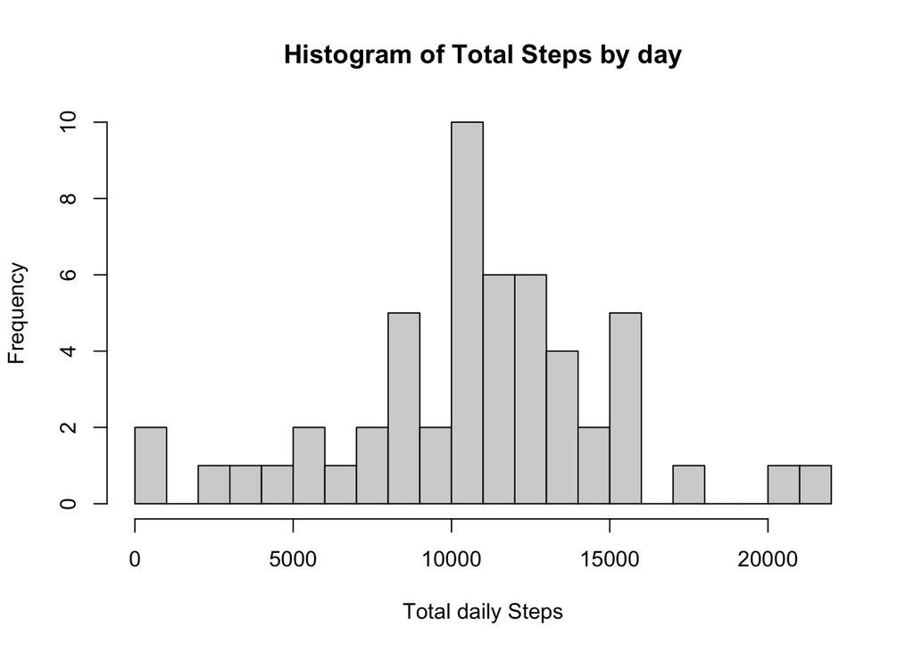

```r
databydate <- stepdata %>% select(date, steps) %>% group_by(date) %>% summarize(tsteps= sum(steps)) %>%na.omit()

hist(databydate$tsteps, xlab = "Total daily Steps",main="Histogram of Total Steps by day", breaks = 20)
```

### 3. The mean and median of the total number of steps taken per day

```r
meanstepsperday<- mean(databydate$tsteps)
medianstepsperday <-median(databydate$tsteps)
```

```r
meanstepsperday
```

```
## [1] 10766.19
```

```r
medianstepsperday
```

```
## [1] 10765
```

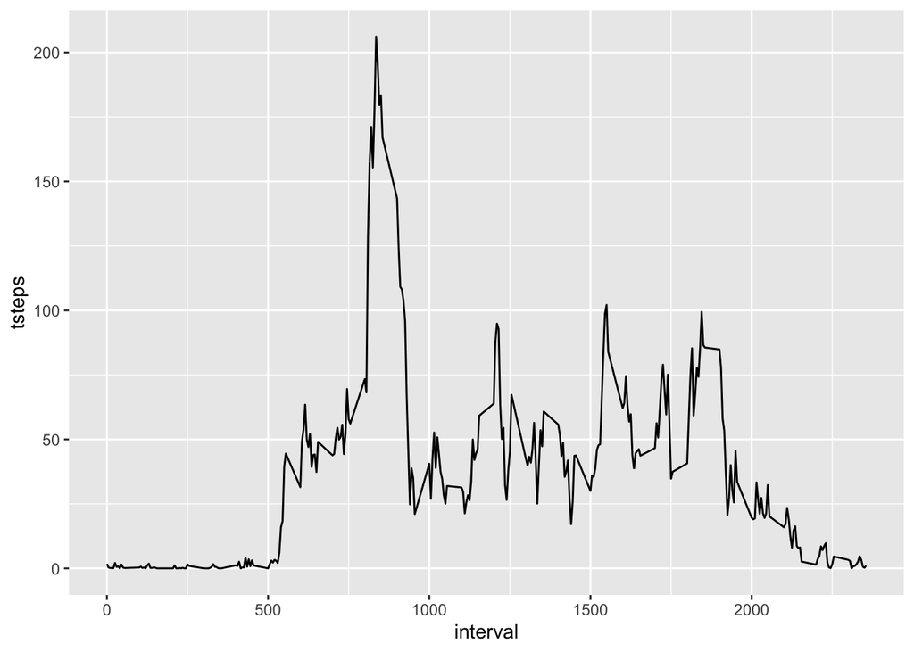

```r
databyinterval <- stepdata%>% select(interval, steps) %>% na.omit() %>% group_by(interval) %>% summarize(tsteps= mean(steps))
ggplot(databyinterval, aes(x=interval, y=tsteps))+ geom_line()
```

### 5.The 5-minute interval that, on average, contains the maximum number of steps

```r
databyinterval[which(databyinterval$tsteps== max(databyinterval$tsteps)),]
```

[output not shown]

### 6. Imputing missing values

We want to calculate and report the total number of missing values in the dataset ( that is the total number of rows with NA’s).

#### a) generate the list of NA’s:

We start by generating the list of NA’s:

```r
missingVals <- sum(is.na(data))
missingVals
```

[output not shown]

#### b) Devise a strategy for filling in all of the missing values in the dataset:

```r
replacewithmean <- function(x) replace(x, is.na(x), mean(x, na.rm = TRUE))
meandata <- stepdata%>% group_by(interval) %>% mutate(steps= replacewithmean(steps))
head(meandata)
```

[output not shown]

### 7. Make a histogram of the total number of steps taken each day and Calculate and report the mean and median total number of steps taken per day

```r
FullSummedDataByDay <- aggregate(meandata$steps, by=list(meandata$date), sum)

names(FullSummedDataByDay)[1] ="date"
names(FullSummedDataByDay)[2] ="totalsteps"
head(FullSummedDataByDay,15)
```

[output not shown]

#### we list the summary of the new data, (which includes the mean and median):

```r
summary(FullSummedDataByDay)
```

```
##      date             totalsteps
##  Length:61          Min.   :   41
##  Class :character   1st Qu.: 9819
##  Mode  :character   Median :10766
##                     Mean   :10766
##                     3rd Qu.:12811
##                     Max.   :21194
```

#### a) The Histogram of the Full summary:

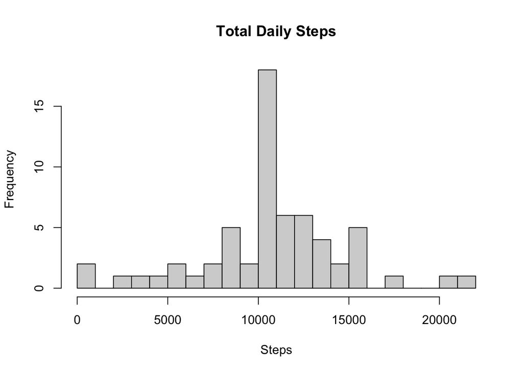

```r
hist(FullSummedDataByDay$totalsteps, xlab = "Steps", ylab = "Frequency", main = "Total Daily Steps", breaks = 20)
```

#### b) a comparision of the means and medians of the old and the new data:

##### b.1) The old mean and New mean:

```r
oldmean <- mean(databydate$tsteps, na.rm = TRUE)
newmean <- mean(FullSummedDataByDay$totalsteps)
oldmean
newmean
```

[output not shown]

##### b.2) old median and new median

```r
oldmedian <- median(databydate$tsteps, na.rm = TRUE)
newmedian <- median(FullSummedDataByDay$totalsteps)
oldmedian
newmedian
```

[output not shown]

### 8. The Answer to the question: are there differences in activity patterns between weekdays and weekends?

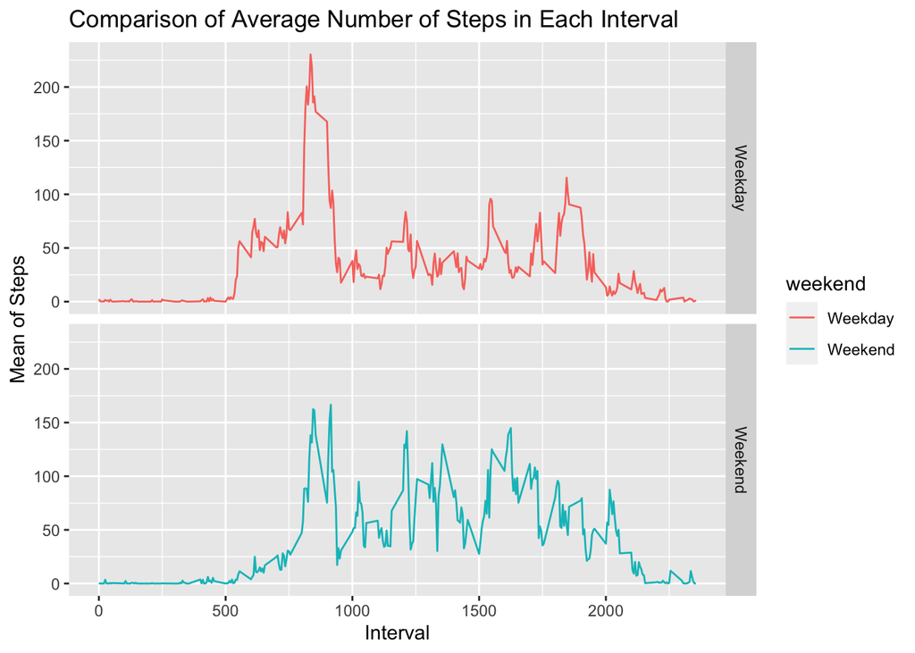

```r
meandata$date <- as.Date(meandata$date)
meandata$weekday <- weekdays(meandata$date)
meandata$weekend <- ifelse(meandata$weekday=="Saturday" | meandata$weekday=="Sunday", "Weekend", "Weekday" )

meandataweekendweekday <- aggregate(meandata$steps , by= list(meandata$weekend, meandata$interval), na.omit(mean))
names(meandataweekendweekday) <- c("weekend", "interval", "steps")

ggplot(meandataweekendweekday, aes(x=interval, y=steps, color=weekend)) + geom_line()+
  facet_grid(weekend ~.) + xlab("Interval") + ylab("Mean of Steps") +
  ggtitle("Comparison of Average Number of Steps in Each Interval")
```